# Analysis of Variance - ANOVA

Manfred Brill

Sommersemester 2021

# 1 ANOVA

Wir haben die Varianzanalyse oder, wie sie mit der englischsprachigen Abkürzung meist kurz genannt wird, ANOVA, bereits an Hand eines Beispiel motiviert und durchgeführt. Jetzt betrachten wir den Einsatz von ANOVA insbesondere in Verbindung mit verschiedenen Designs von Experimenten.

Die Funktion *aov*, die wir verwendet haben gibt es einmal im *stats*-Package in der Default-Installation, jedoch auch in mehreren anderen Packages wie *car*. Interessant ist das Package *rstatix*, zu dem es eine gute Web-Site und ein Buch gibt und das sich dadurch auszeichnet, dass die Funktionen sich gut in Pipelines integrieren lassen, die wir mit *tidyverse* implementieren. Insbesondere bei zwei oder mehr Faktoren werden wir sehen, dass das sehr nützlich ist. Zu *rstatix* gibt es ein weiteres Package *datarium* mit Datensätzen. Für paarweise Vergleiche verwendet das Package *rstatix* die Library *emmeans*. Insgesamt sollten Sie überprüfen, ob die folgenden Packages installiert sind

1. *car*
2. *multcomp*
3. *rstatix*
4. *ggpubr*
5. *datarium*
6. *emmeans*

Im folgenden verwenden wir Daten wie im Kapitel 9 *Analysis of Variance* in (Kabacoff 2015), insbesondere die Datensätze, die dort angegeben werden. Weitere Einzelheiten zu den Funktionen sind (Kassambara 2019) entnommen.

Wir verwenden häufig nicht die Default-Funktion *aov* aus dem *stats*-Package, sondern die Funktion *anova_test* aus dem *rstatix*-Package, die in (Kassambara 2019) vorgestellt wird. Eigentlich ist diese Funktion wiederrum nur ein Wrapper um die *aov*-Funktion aus demn *car* Package, die zuverlässiger arbeitet als die Default-Funktion. Die Inhalte von (Kassambara 2019) findet man online auf (Datanovia 2021).

# 2 Einfaktorielle Varianzanalyse - One-Way ANOVA

## 2.1 Beschreibung der Daten

Wir betrachten ein Experiment, das neben der gemessenen Variable, die wir immer *response* nennen einen Faktor, also mehrere Stufen enthält. Die Stufen bezeichnen wir meist als *treatment* oder kurz *trt*.

Als Daten verwenden wir *cholesterol* aus dem Package *multcomp*. Der folgende Text ist dem Hilfetext entnommen, den wir mit *?cholesterol* abrufen können. Dort finden wir auch eine Literaturangabe für die Daten:

“*A clinical study was conducted to assess the effect of three formulations of the same drug on reducing cholesterol. The formulations were 20mg at once (1time), 10mg twice a day (2times), and 5mg four times a day (4times). In addition, two competing drugs were used as control group (drugD and drugE). The purpose of the study was to find which of the formulations, if any, is efficacious and how these formulations compare with the existing drugs.*”

Offensichtlich liegen fünf Stufen eines Faktors vor. Als Variable *response* finden wir die Reduktion des Cholestorol-Gehalts in Prozent. Die fünf Faktoren finden wir in der Spalte *trt*. Untersucht werden drei Dosierungen eines Medikaments, wobei diese Ergebnisse mit Kontrollgruppen verglichen werden, denen die alternativen Medikamente *drugD* und *drugE* verabreicht wurden.

Wir bestimmen mit einer *tidyverse*-Pipeline die Anzahlen für die verschiedenen Stufen, die Mittelwerte und die Standardabweichungen. Wir erkennen, dass wir jeweils 10 Einträge pro Stufe in den Daten vorfinden. Die Mittelwerte scheinen sich stark zu unterscheiden. Anschließend erstellen wir mit Hilfe der Funktion *plotmeans* eine grafische Darstellung mit einem Konfidenzniveau von 95%.

```r
cholesterol %>%
  group_by(trt) %>%
  summarize(Anzahl=n(),
            Mittelwerte=mean(response),
            Standardabweichungen=sd(response),
            .groups="keep")
```

| trt | Anzahl | Mittelwerte | Standardabweichungen |
| --- | --- | --- | --- |
| 1time | 10 | 5.782 | 2.878 |
| 2times | 10 | 9.225 | 3.483 |
| 4times | 10 | 12.375 | 2.923 |
| drugD | 10 | 15.361 | 3.455 |
| drugE | 10 | 20.948 | 3.345 |

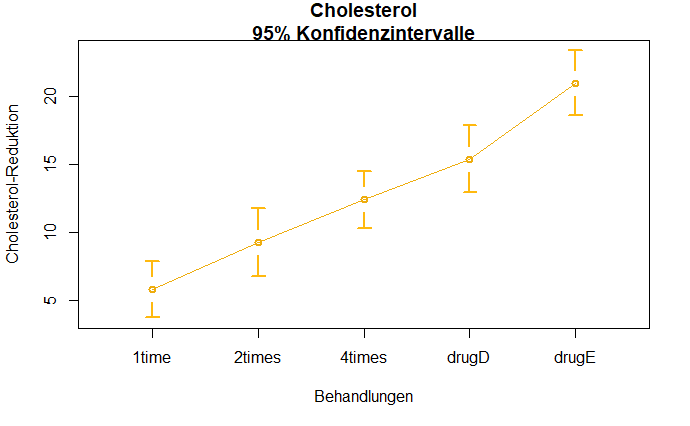

```r
plotmeans(response ~ trt, data=cholesterol,
          xlab="Behandlungen",
          ylab="Cholesterol-Reduktion",
          col="darkgoldenrod2",
          n.label=FALSE,
          use.t=TRUE,
          barwidth=2,
          barcol="darkgoldenrod1",
          main='Cholesterol\n95% Konfidenzintervalle')
```

Die Konfidenzintervall und die Standardabweichungen zeigen uns, dass die Bereiche überlappen. Wir erkennen aber auch sehr deutlich, dass die Behandlung mit *drugE* die beste Reduktion erzielt hat.

## 2.2 Hypothesentests

Wir verwenden die Funktion *aov* aus dem *stats*-Package und die Funktion *anova_test* aus dem Package *rstatix*. Hier werden verschiedenen Ansätze für die Berechnung der Quadratsummen eingesetzt, aber die F-Werte und die p-Werte sind für beide Funktionen identisch.

Zur Erinnerung: die Nullhypothese ist, dass alle fünf Erwartungswerte der Cholesterol-Reduktion identisch sind. Die Gegenhypothese ist, dass sich mindestens zwei der Erwartungswerte unterscheiden. Aus den Zahlen und der grafischen Ausgabe könnte man bereits vorhersagen, dass wir die Nullhypothese verworfen werden.

```r
fit <- aov(response ~ trt, data=cholesterol)
summary(fit)
```

```
            Df Sum Sq Mean Sq F value  Pr(>F)
trt          4   1351     338    32.4 9.8e-13 ***
Residuals   45    469      10
---
Signif. codes:  0 ‘***’ 0.001 ‘**’ 0.01 ‘*’ 0.05 ‘.’ 0.1 ‘ ’ 1
```

```r
dn.fit <- cholesterol %>%
  anova_test(response ~ trt)
```

```
Coefficient covariances computed by hccm()
```

```r
dn.fit
```

```
ANOVA Table (type II tests)

  Effect DFn DFd     F        p p<.05   ges
1    trt   4  45 32.43 9.82e-13     * 0.742
```

Unsere Vorhersage ist bestätigt, mit diesen p-Werten verwerfen wir die Nullhypothese, die Erwartungswerte in der Cholesterol-Reduktion unterscheiden sich.

## 2.3 Paarweise Vergleiche

Jetzt stellt sich sofort die Frage, welche Stufen bzw. Behandlungen sich von welchen signifikant unterscheiden. Die Statistik kennt hier mehrere Verfahren. Als erste Funktion verwenden wir *TukeyHSD*. Dabei steht *HSD* für den von Tukey vorgeschlagenen Algorithmus *Honest Significant Differences*. Diese Funktion bildet paarweise Vergleiche zwischen den Mittelwerten in den verschiedenen Stufen. Wir können das Ergebnis dieser Funktion der *plot*-Funktion übergeben und erhalten so eine grafische Ausgabe.

```r
(tukey <- TukeyHSD(fit))
```

```
  Tukey multiple comparisons of means
    95% family-wise confidence level

Fit: aov(formula = response ~ trt, data = cholesterol)

$trt
                diff     lwr    upr  p adj
2times-1time   3.443 -0.6583  7.544 0.1381
4times-1time   6.593  2.4915 10.694 0.0004
drugD-1time    9.579  5.4779 13.680 0.0000
drugE-1time   15.166 11.0643 19.267 0.0000
4times-2times  3.150 -0.9515  7.251 0.2050
drugD-2times   6.136  2.0349 10.237 0.0010
drugE-2times  11.723  7.6213 15.824 0.0000
drugD-4times   2.986 -1.1149  7.088 0.2512
drugE-4times   8.573  4.4715 12.674 0.0000
drugE-drugD    5.586  1.4851  9.688 0.0031
```

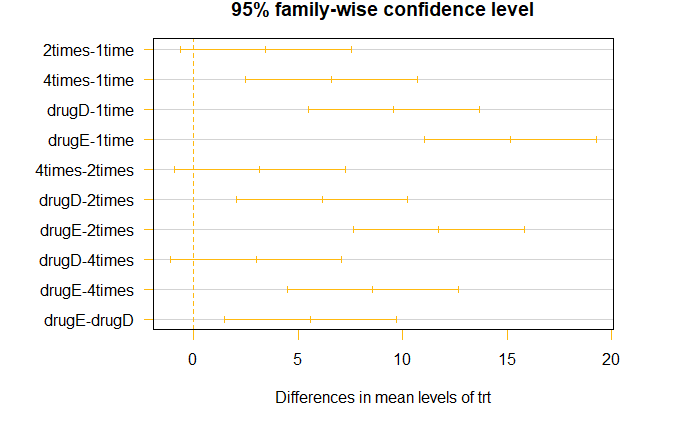

```r
par(las=2)
par(mar=c(5,8,2,4))
plot(tukey, las=1, col="darkgoldenrod1")
```

An Hand der p-Werte in der Ausgabe der Funktion *tukeyHSD* wir erkennen wir, ob es in einem Paar von Stufen einen signifikanten Unterschied gibt. Der p-Wert für das Paar *2times-1time* liegt bei 0.1381. Signifkant ist der Unterschied im Paar *4times-1time*, hier wird ein p-Wert von 0.0004 angegeben. Wie schon bei den grafischen Ausgaben vorher ist deutlich zu sehen, dass *drugE* die beste Reduktion hervorruft.

In der grafischen Ausgabe der Konfidenzintervalle sind die Paare, für die das dargestellte Intervall die 0 enthält diejenigen, die keinen signifikanten Unterschied in den Erwartungswerten besitzen.

Mit Hilfe der Funktion *glht* im Package *multcomp* können wir eine weitere grafische Darstellung für die paarweisen Unterschiede erstellen. Der bereits durchgeführte Tukey-Test wird wieder durchgeführt und die Ergebnisse werden mit Hilfe von Box-Plots ausgegeben. Dabei verwenden wir die Funktion *cld*, die paarweise Vergleiche mit Hilfe von Buchstabenkombinationen darstellt.

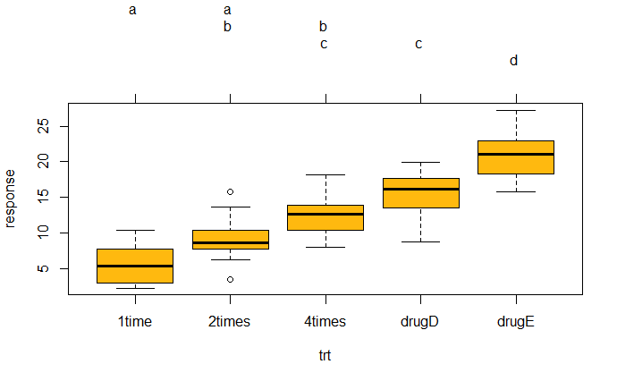

```r
par(mar=c(5, 4, 6, 2))
tukey <- glht(fit, linfct=mcp(trt="Tukey"))
plot(cld(tukey, level=0.05), col="darkgoldenrod1")
```

Stufen, die gemeinsame Buchstaben-Codes haben wie *2times* oder *4times* haben keine signifikanten Unterschiede in den Erwartungswerten. Die Stufe *4times* ist besser als *1times*. Die Stufe *drugD* ist ergibt nicht signifikant bessere Ergebnisse als *4times*, bei beiden Stufen finden wir in der Ausgabe den Buchstaben c. Wieder erkennen wir, dass *drugE* signifikant besser ist als alle anderen.

Auch das Package *rstatix* enthält eine Funktion mit der wir die p-Werte für die einzelnen Kombinationen berechnen können:

```r
pwc <- cholesterol %>%
  tukey_hsd(response ~ trt)

kable(pwc, align="l",
      caption="Die paarweisen Vergleiche mit der Funktion tukey_hsd") %>%
      kable_styling(bootstrap_options = c("striped", "condensed"),
                full_width = T,
                position = "center")
```

Die paarweisen Vergleiche mit der Funktion tukey_hsd

| term | group1 | group2 | null.value | estimate | conf.low | conf.high | p.adj | p.adj.signif |
| --- | --- | --- | --- | --- | --- | --- | --- | --- |
| trt | 1time | 2times | 0 | 3.443 | -0.6583 | 7.544 | 0.1380 | ns |
| trt | 1time | 4times | 0 | 6.593 | 2.4915 | 10.694 | 0.0004 | *** |
| trt | 1time | drugD | 0 | 9.579 | 5.4779 | 13.681 | 0.0000 | **** |
| trt | 1time | drugE | 0 | 15.166 | 11.0643 | 19.267 | 0.0000 | **** |
| trt | 2times | 4times | 0 | 3.150 | -0.9515 | 7.251 | 0.2050 | ns |
| trt | 2times | drugD | 0 | 6.136 | 2.0349 | 10.238 | 0.0010 | *** |
| trt | 2times | drugE | 0 | 11.723 | 7.6213 | 15.824 | 0.0000 | **** |
| trt | 4times | drugD | 0 | 2.986 | -1.1149 | 7.088 | 0.2510 | ns |
| trt | 4times | drugE | 0 | 8.573 | 4.4715 | 12.674 | 0.0000 | **** |
| trt | drugD | drugE | 0 | 5.586 | 1.4851 | 9.688 | 0.0031 | ** |

Wir können das Tibble *pwc* (die Abkürzung steht für *pairweise comparison*) mit Hilfe von *ggplot2* ausgeben:

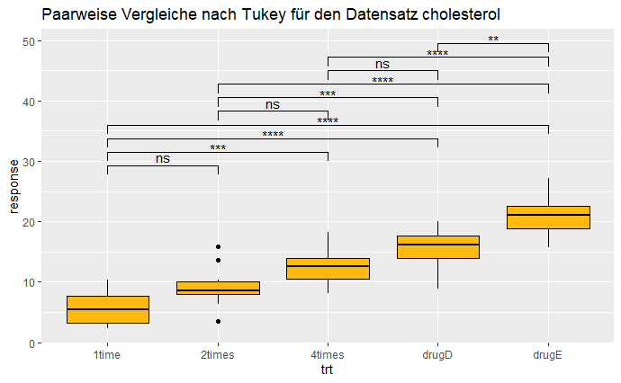

```r
pwc <- pwc %>%
  add_xy_position(x = "trt")

ggplot(data=cholesterol, aes(x=trt, y = response)) +
  geom_boxplot(fill="darkgoldenrod1", color="black") +
  stat_pvalue_manual(pwc, hide.ns=FALSE) +
  labs(
    title="Paarweise Vergleiche nach Tukey für den Datensatz cholesterol"
  )
```

Auch hier finden wir die p-Werte für die verschiedenen Paare der Stufen.

## 2.4 Überprüfung der Voraussetzungen

In der Annahme für die Verwendung der Funktion *aov* steckt insbesondere, dass die untersuchte Größe normalverteilt ist und die Varianzen in den Faktoren gleich sind. Das können wir mit Hilfe eines Q-Q Plots überprüfen.

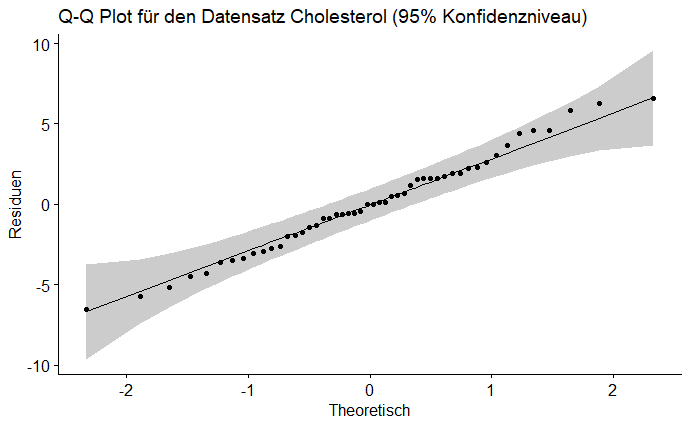

```r
model <- lm(response~trt, data =cholesterol)
ggqqplot(residuals(model), title="Q-Q Plot für den Datensatz Cholesterol (95% Konfidenzniveau)", xlab="Theoretisch", ylab = "Residuen", panel.labs = TRUE)
```

Die Punkte, die zu den Samples gehören fallen in das angezeigte 95%-Konfidenzintervall, also gehen wir davon aus, dass die Annahme der Normalverteilung gegeben ist.

Alternativ können wir einen sogenannte Bartlett- oder einen Shapiro-Testdurchführen. Die Nullhypothese für diese Hypothesentests ist, dass sich die Varianzen in den fünf Gruppen nicht stark unterscheiden.

```r
bartlett.test(response~trt, data=cholesterol)
```

```
    Bartlett test of homogeneity of variances

data:  response by trt
Bartlett's K-squared = 0.58, df = 4, p-value = 1
```

```r
shapiro_test(residuals(model))
```

| variable | statistic | p.value |
| --- | --- | --- |
| residuals(model) | 0.9886 | 0.9094 |

Wir erhalten eine Wahrscheinlichkeit von 1 bzw. 0.9094, dass sich die Varianzen nicht stark unterscheiden, also verwerfen wir diese Nullhypothese nicht.

# 3 Zweifaktorielle Varianzanalyse - Two-Way ANOVA

## 3.1 Beschreibung der Daten

Jetzt betrachten wir den Fall, dass zwei Faktoren vorliegen, Wir verwenden wie in (Kabacoff 2015) den Datensatz *ToothGrowth*, der in der Standard-Installation von R enthalten ist. Hier sind Daten enthalten, die den Effekt von Vitamin C auf das Wachstum der Zähne bei Meerschweinchen (“guinea pigs”) beschreiben. Der folgende Text ist dem Hilfetext entnommen, den wir mit *?ToothGrowth* abrufen können. Dort finden wir auch eine Literaturangabe für die Daten:

“*The response is the length of odontoblasts (cells responsible for tooth growth) in 60 guinea pigs. Each animal received one of three dose levels of vitamin C (0.5, 1, and 2 mg/day) by one of two delivery methods, orange juice or ascorbic acid (a form of vitamin C and coded as VC).*”

Wir geben die ersten Zeilen der Daten als Tabelle aus:

```r
kable(head(ToothGrowth), align="l",
      caption="Tabelle 1: Der Datensatz ToothGrowth") %>%
      kable_styling(bootstrap_options = c("striped", "condensed"),
                full_width = T,
                position = "center")
```

Tabelle 1: Der Datensatz ToothGrowth

| len | supp | dose |
| --- | --- | --- |
| 4.2 | VC | 0.5 |
| 11.5 | VC | 0.5 |
| 7.3 | VC | 0.5 |
| 5.8 | VC | 0.5 |
| 6.4 | VC | 0.5 |
| 10.0 | VC | 0.5 |

Wichtig bei den beiden Spalten, die wir als Levels für das Experiment verwenden ist, dass sie vom Datentyp *factor* sind. Das sollte man immer überprüfen, mit Hilfe der Funktion *is.factor*. Hier stellen wir auch fest, dass die Spalte *dose* noch den falschen Datentyp hat, was wir korrigieren:

```r
is.factor(ToothGrowth$supp)
```

```
[1] TRUE
```

```r
is.factor(ToothGrowth$dose)
```

```
[1] FALSE
```

```r
ToothGrowth$dose <- factor(ToothGrowth$dose)
is.factor(ToothGrowth$dose)
```

```
[1] TRUE
```

In der Tabelle erkennen wir, dass drei Spalten vorliegen. In der Spalte mit der Bezeichnung *len* finden wir die Länge der Zähne, leider ohne Einheit. Die Spalte *supp* gibt an, wie die Ascorbinsäure verabreicht wurde: entweder in Form von Orangensaft (*OJ*, “orange juice”) oder direkt als Vitamin C (*VC*). Es wurde drei Stufen für die Ascorbinsäure verwendet, nämlich 0.5, 1 oder 2 mg.

Jetzt aggregieren wir wieder die kardinale Spalte und berücksichtigen dabei die beiden Faktoren:

```r
aggregation <- ToothGrowth %>%
  group_by(supp, dose) %>%
  summarize(Anzahl = n(),
            Mittelwerte=mean(len),
            Standardabweichungen=sd(len),
            .groups="keep")

kable(aggregation, align="l",
      caption="Tabelle 2: Aggregierter Datensatz ToothGrowth") %>%
      kable_styling(bootstrap_options = c("striped", "condensed"),
                full_width = T,
                position = "center")
```

Tabelle 2: Aggregierter Datensatz ToothGrowth

| supp | dose | Anzahl | Mittelwerte | Standardabweichungen |
| --- | --- | --- | --- | --- |
| OJ | 0.5 | 10 | 13.23 | 4.460 |
| OJ | 1 | 10 | 22.70 | 3.911 |
| OJ | 2 | 10 | 26.06 | 2.655 |
| VC | 0.5 | 10 | 7.98 | 2.747 |
| VC | 1 | 10 | 16.77 | 2.515 |
| VC | 2 | 10 | 26.14 | 4.798 |

Es gibt 60 Einträge, die sich gleichmässig auf die 6 möglichen Kombinationen verteilen - es liegt ein *balanced design* vor. Wir erkennen auch, dass es durchaus Unterschiede zwischen den verschiedenen Mittelwerten der Zahnlängen gibt. Ob diese Unterschiede signifikant sind oder nicht muss der Hypothesentest erweisen.

Bevor wir den Hypothesentest durchführen erstellen wir einen Boxplot, bei dem wir ebenfalls beide Faktoren berücksichtigen.

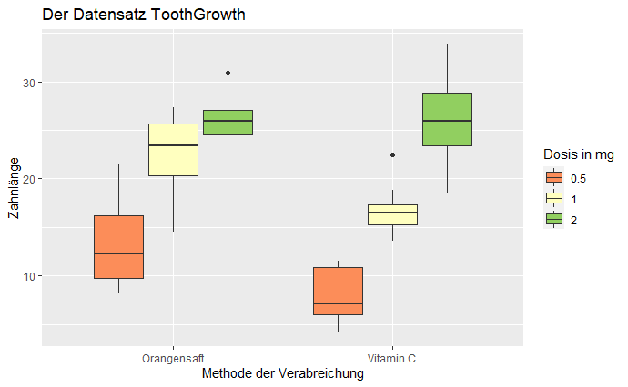

```r
ggplot(ToothGrowth, aes(x=supp, y = len)) +
  geom_boxplot(aes(fill=dose)) +
  scale_fill_brewer(palette="RdYlGn") +
  scale_x_discrete(labels=c("Orangensaft", "Vitamin C")) +
  labs(
    title = "Der Datensatz ToothGrowth",
    x = "Methode der Verabreichung",
    y = "Zahnlänge"
  ) +
  guides(fill=guide_legend(title="Dosis in mg"))
```

Man erkennt auch hier durchaus eine Unterscheidung, insbesondere scheint es einen Zusammenhang zwischen der verwendeten Dosis und der Länge der Zähne zu geben.

## 3.2 Voraussetzungen für die Durchführung des Hypothesentests

Wir hatten bereits festgehalten, dass wir überprüfen können, ob die Bedingungen für die Varianzanalyse erfüllt sind, insbesondere ob die Stichproben normalverteilt sind. Wir erstellen einen Q-Q-Plot, dabei verwenden wir wie später auch ein Modell der Form *len ~ supp*dose*:

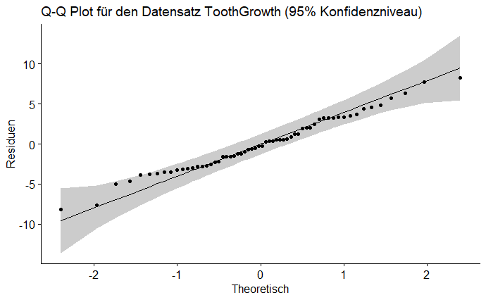

```r
model <- lm(len ~ supp*dose, data = ToothGrowth)

ggqqplot(residuals(model), title="Q-Q Plot für den Datensatz ToothGrowth (95% Konfidenzniveau)", xlab="Theoretisch", ylab = "Residuen", panel.labs = TRUE)
```

```r
shapiro_test(residuals(model))
```

| variable | statistic | p.value |
| --- | --- | --- |
| residuals(model) | 0.985 | 0.6694 |

```r
ToothGrowth %>%
  group_by(supp, dose) %>%
  shapiro_test(len)
```

| supp | dose | variable | statistic | p |
| --- | --- | --- | --- | --- |
| OJ | 0.5 | len | 0.8927 | 0.1820 |
| OJ | 1 | len | 0.9266 | 0.4153 |
| OJ | 2 | len | 0.9626 | 0.8148 |
| VC | 0.5 | len | 0.8900 | 0.1696 |
| VC | 1 | len | 0.9083 | 0.2698 |
| VC | 2 | len | 0.9733 | 0.9194 |

Der p-Wert des Shapiro-Tests und der Q-Q Plot sprechen dafür, dass die Vorbedingungen für die erfüllt sind. Wir führen den Shapiro-Test auch gruppenweise durch, auch hier sehen wir p-Werte, die dafür sprechen den Hypothesentest durchzuführen.

Mit Hilfe von *facet_grid* in *ggplot2* können wir auch die Q-Q Plots gruppenweise durchführen.

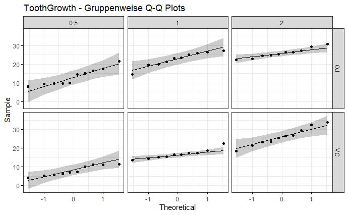

```r
ggqqplot(ToothGrowth, "len", ggtheme=theme_bw()) +
  labs(
    title = "ToothGrowth - Gruppenweise Q-Q Plots"
  ) +
  facet_grid(supp ~ dose)
```

## 3.3 Hypothesentest

Jetzt führen wir die Varianzanalyse durch. Dabei verwenden wir eine Pipeline und die Funktion *anova_test*.

```r
(aov.test <- ToothGrowth %>%
  anova_test(len ~ supp*dose))
```

```
Coefficient covariances computed by hccm()
```

```
ANOVA Table (type II tests)

     Effect DFn DFd      F        p p<.05   ges
1      supp   1  54 15.572 2.31e-04     * 0.224
2      dose   2  54 92.000 4.05e-18     * 0.773
3 supp:dose   2  54  4.107 2.20e-02     * 0.132
```

In der Ausgabe des Hypothesentests erkennen wir drei Zeilen. Die beiden Faktoren werden bewertet, beide sind offensichtlich signifikant. Die dritte Zeile mit dem Eintrag *supp:dose* bewertet die Interaktion zwischen den beiden Faktoren. Auch diese Interaktion ist signifikant. Wir verwerfen die Nullhypothese.

## 3.4 Analyse nach dem Test - post-hoc analysis

Nachdem wir festgestellt haben, dass beide Faktoren und auch ihre Interaktion einen signifikanten Einfluss auf die Länge der Zähne haben erstellen wir nun einfaktorielle Varianzanalysen in den Gruppen. Konkret gruppieren wir die Daten nach der Art der Verabreichung und analysieren den Einfluss der Dosierung für jeden dieser Level als One-Way Anova. Dabei berechnen wir vorher den Gesamtfehler der Two-Way ANOVA und übergeben diesen Wert an die Aufrufe von *anova_test*:

```r
model <- lm(len ~ supp*dose, data=ToothGrowth)

ToothGrowth %>%
  group_by(supp) %>%
  anova_test(len ~ dose, error=model)
```

```
Coefficient covariances computed by hccm()
Coefficient covariances computed by hccm()
```

|  | supp | Effect | DFn | DFd | F | p | p<.05 | ges |
| --- | --- | --- | --- | --- | --- | --- | --- | --- |
| 1 | OJ | dose | 2 | 54 | 33.56 | 3.36e-10 | * | 0.554 |
| 2 | VC | dose | 2 | 54 | 62.54 | 8.75e-15 | * | 0.698 |

```r
model <- lm(len ~ supp*dose, data=ToothGrowth)

ToothGrowth %>%
  emmeans_test(
    len ~ dose, p.adjust.method = "bonferroni",
    model = model
  )
```

```
NOTE: Results may be misleading due to involvement in interactions
```

|  | term | .y. | group1 | group2 | df | statistic | p | p.adj | p.adj.signif |
| --- | --- | --- | --- | --- | --- | --- | --- | --- | --- |
| 1 | dose | len | 0.5 | 1 | 54 | -7.951 | 1.186e-10 | 3.557e-10 | **** |
| 2 | dose | len | 0.5 | 2 | 54 | -13.493 | 6.173e-19 | 1.852e-18 | **** |
| 3 | dose | len | 1 | 2 | 54 | -5.543 | 9.121e-07 | 2.736e-06 | **** |

```r
ToothGrowth %>%
  pairwise_t_test(len ~ dose,
                  p.adjust.method = "bonferroni"
                  )
```

|  | .y. | group1 | group2 | n1 | n2 | p | p.signif | p.adj | p.adj.signif |
| --- | --- | --- | --- | --- | --- | --- | --- | --- | --- |
| 1 | len | 0.5 | 1 | 20 | 20 | 6.70e-09 | **** | 2.01e-08 | **** |
| 2 | len | 0.5 | 2 | 20 | 20 | 1.47e-16 | **** | 4.41e-16 | **** |
| 3 | len | 1 | 2 | 20 | 20 | 1.44e-05 | **** | 4.33e-05 | **** |

```r
pwc <- ToothGrowth %>%
  group_by(supp) %>%
  emmeans_test(len ~ dose,
               p.adjust.method="bonferroni"
                  )

pwc
```

|  | supp | term | .y. | group1 | group2 | df | statistic | p | p.adj | p.adj.signif |
| --- | --- | --- | --- | --- | --- | --- | --- | --- | --- | --- |
| 1 | OJ | dose | len | 0.5 | 1 | 54 | -5.831 | 3.176e-07 | 9.527e-07 | **** |
| 2 | OJ | dose | len | 0.5 | 2 | 54 | -7.900 | 1.430e-10 | 4.289e-10 | **** |
| 3 | OJ | dose | len | 1 | 2 | 54 | -2.069 | 4.335e-02 | 1.301e-01 | ns |
| 4 | VC | dose | len | 0.5 | 1 | 54 | -5.413 | 1.463e-06 | 4.389e-06 | **** |
| 5 | VC | dose | len | 0.5 | 2 | 54 | -11.182 | 1.131e-15 | 3.392e-15 | **** |
| 6 | VC | dose | len | 1 | 2 | 54 | -5.770 | 3.981e-07 | 1.194e-06 | **** |

Die einzige nicht signifikante Kombination ist die in Zeile 3. Wir verabreichen Orangensaft, in dem Fall gibt es keinen signifikanten Unterschied bei den Dosierungen 1 mg und 2 mg.

Wir erstellen einen Boxplot, indem wir dies gut erkennen:

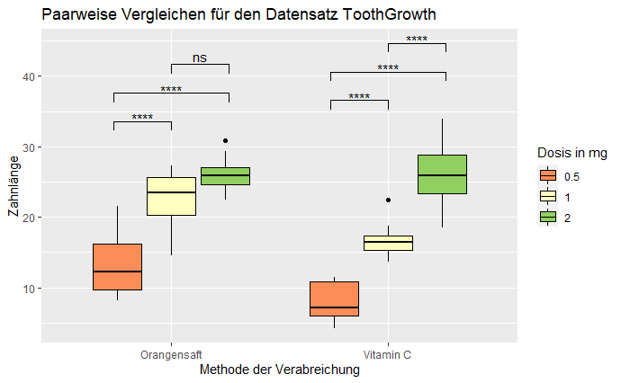

```r
pwc <- pwc %>%
  add_xy_position(x = "supp")

ggplot(data=ToothGrowth, aes(x=supp, y = len)) +
  geom_boxplot(aes(fill=dose), color="black") +
  stat_pvalue_manual(pwc, hide.ns=FALSE) +
  scale_fill_brewer(palette="RdYlGn") +
  scale_x_discrete(labels=c("Orangensaft", "Vitamin C")) +
  labs(
    title = "Paarweise Vergleichen für den Datensatz ToothGrowth",
    x = "Methode der Verabreichung",
    y = "Zahnlänge"
  ) +
  guides(fill=guide_legend(title="Dosis in mg"))
```

# 4 Ausblick

## 4.1 dreifaktorielle Varianzanalyse

Natürlich können wir jetzt zu drei oder noch mehr Faktoren übergeben, was wir aber nur kurz betrachten werden. Eine gute Beschreibung dafür finden wir auf (Datanovia 2021). Wir verwenden die dort eingesetzten Daten aus dem Package *datarium* und führen die Varianzanalyse durch.

Die Daten stammen aus dem Datensatz *headache* und beschreiben drei Faktoren für Migräne-Anfälle. Die Stärke der Migräne wird im kardinalen Merkmale *pain_score* gemessen. Es wird die Auswirkung von drei Medikamenten *X*, *Y* und *Z* untersucht. Die Teilnehmer bestehen aus 36 Frauen und 36 Männern, die nochmals unterteilt werden, darauf hin ob ihr Migräne-Risiko klein oder groß ist. Wir ziehen aus dem Datensatz, der nach *library(datarium)* verfügbar ist einige Zeilen heraus und achten dabei darauf, dass jede der möglichen Kombinationen enthalten ist:

```r
set.seed(42)
headache %>%
  sample_n_by(gender, risk, treatment, size=1)
```

| id | gender | risk | treatment | pain_score |
| --- | --- | --- | --- | --- |
| 19 | male | high | X | 94.09 |
| 29 | male | high | Y | 91.18 |
| 31 | male | high | Z | 74.42 |
| 1 | male | low | X | 79.31 |
| 8 | male | low | Y | 80.68 |
| 16 | male | low | Z | 78.91 |
| 56 | female | high | X | 82.66 |
| 62 | female | high | Y | 73.14 |
| 67 | female | high | Z | 74.99 |
| 40 | female | low | X | 71.25 |

[output cut: 2 more lines]

Wir können wieder die Anzahlen, die Mittelwerte und die Standardabweichungen mit Hilfe einer Pipeline berechnen.

```r
aggregation <- headache %>%
  group_by(gender, risk, treatment) %>%
  summarize(Anzahl = n(),
            Mittelwerte=mean(pain_score),
            Standardabweichungen=sd(pain_score),
            .groups="keep")

kable(aggregation, align="l",
      caption="Tabelle 3: Aggregierter Datensatz headache") %>%
      kable_styling(bootstrap_options = c("striped", "condensed"),
                full_width = T,
                position = "center")
```

Tabelle 3: Aggregierter Datensatz headache

| gender | risk | treatment | Anzahl | Mittelwerte | Standardabweichungen |
| --- | --- | --- | --- | --- | --- |
| male | high | X | 6 | 92.74 | 5.116 |
| male | high | Y | 6 | 82.34 | 5.001 |
| male | high | Z | 6 | 79.68 | 4.046 |
| male | low | X | 6 | 76.05 | 3.855 |
| male | low | Y | 6 | 73.14 | 4.765 |
| male | low | Z | 6 | 74.46 | 4.889 |
| female | high | X | 6 | 78.87 | 5.316 |
| female | high | Y | 6 | 81.18 | 4.619 |
| female | high | Z | 6 | 81.04 | 3.985 |
| female | low | X | 6 | 74.16 | 3.690 |
| female | low | Y | 6 | 68.36 | 4.082 |
| female | low | Z | 6 | 69.78 | 2.720 |

Wir haben wieder ein balanciertes Design, von jeder Kombination liegen 6 Zeilen vor. Auch Box-Plots können wir wie schon vorher erstellen, allerdings verwenden wir für den dritten Faktor die Funktion *facet_grid*.

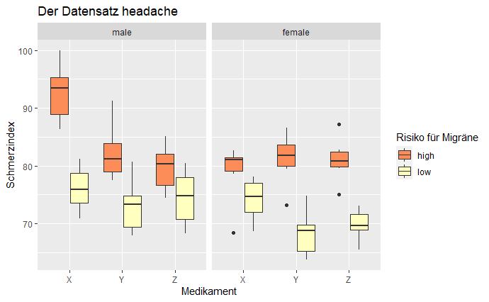

```r
ggplot(headache, aes(x=treatment, y = pain_score)) +
  geom_boxplot(aes(fill=risk)) +
  scale_fill_brewer(palette="RdYlGn") +
  scale_x_discrete(labels=c("X", "Y", "Z")) +
  labs(
    title = "Der Datensatz headache",
    x = "Medikament",
    y = "Schmerzindex"
  ) +
  guides(fill=guide_legend(title="Risiko für Migräne")) +
  facet_grid(~gender)
```

Wir verzichten jetzt auf die Q-Q Plots und weitere Checks, ob die Voraussetzungen für den Einsatz der Varianzanalyse gegeben sind und führen direkt den Test durch.

```r
(aov.test <- headache %>%
  anova_test(pain_score ~ gender*risk*treatment))
```

```
Coefficient covariances computed by hccm()
```

```
ANOVA Table (type II tests)

                 Effect DFn DFd      F        p p<.05   ges
1                gender   1  60 16.196 1.63e-04     * 0.213
2                  risk   1  60 92.699 8.80e-14     * 0.607
3             treatment   2  60  7.318 1.00e-03     * 0.196
4           gender:risk   1  60  0.141 7.08e-01       0.002
5      gender:treatment   2  60  3.338 4.20e-02     * 0.100
6        risk:treatment   2  60  0.713 4.94e-01       0.023
7 gender:risk:treatment   2  60  7.406 1.00e-03     * 0.198
```

Es gibt eine signifikante Interaktionen zwischen allen drei Faktoren. Und es gibt zwei nicht-signifikante Interaktionen, einmal zwischen Geschlecht und Migräne-Risiko und zwischen Migräne-Risko und Medikament.

Anschließend führen wir eine Gruppierung nach Geschlecht durch und innerhalb der so entstehenden Gruppen eine zweifaktorielle Varianzanalyse. Hier wird sehr deutlich, dass wir vom Einsatz von *tidyverse* und den Pipelines profitieren:

```r
model <- lm(pain_score ~ gender*risk*treatment, data = headache)
headache %>%
  group_by(gender) %>%
  anova_test(pain_score ~ risk*treatment, error =model)
```

```
Coefficient covariances computed by hccm()
Coefficient covariances computed by hccm()
```

|  | gender | Effect | DFn | DFd | F | p | p<.05 | ges |
| --- | --- | --- | --- | --- | --- | --- | --- | --- |
| 1 | male | risk | 1 | 60 | 50.037 | 1.87e-09 | * | 0.455 |
| 2 | male | treatment | 2 | 60 | 10.174 | 1.57e-04 | * | 0.253 |
| 3 | male | risk:treatment | 2 | 60 | 5.252 | 8.00e-03 | * | 0.149 |
| 4 | female | risk | 1 | 60 | 42.803 | 1.50e-08 | * | 0.416 |
| 5 | female | treatment | 2 | 60 | 0.482 | 6.20e-01 |  | 0.016 |
| 6 | female | risk:treatment | 2 | 60 | 2.868 | 6.50e-02 |  | 0.087 |

Wir erhalten eine signifikante Interaktion zwischen verabreichtem Medikament und dem Migräne-Risiko bei den Männern mit p=0.008, jedoch nicht bei den weiblichen Teilnehmerinnen. Offensichtlich beeinflusst das Migräne-Risiko den Effekt des verabreichten Medikaments.

Anschließend kann man für die männlichen Teilnehmer weiter analysieren und paarweise Vergleiche anstellen und visualieren, worauf wir an dieser Stelle jedoch verzichten.

## 4.2 Kovarianzanalyse - ANCOVA

Eine Kovarianzanalyse ist sehr stark verwandt mit der Varianzanalyse, die wir bisher untersucht haben. ANCOVA führen wir dann durch, wenn wir ein kardinales Merkmal analysieren und einen oder mehrere Faktoren vorliegen haben. Zusätzlich untersuchen wir jetzt noch den Einfluss eines weiteren kardinalen Merkmals. Ein Beispiel für eine solche Analyse wären Prüfungsergebnisse in Abhängigkeit vom Faktor der Ausbildung unter Berücksichtigung der Anzahl der Stunden, die für die Vorbereitung eingesetzt wurden.

“ *Pregnant mice were divided into four groups and the compound in four different doses was administered during pregnancy. Their litters were evaluated for birth weights.* ”

Wir führen wieder eine Aggregation durch. Dabei stellen wir fest, dass für die unterschiedlichen Dosierungen unterschiedlich viele Versuchstiere eingesetzt wurden.

```r
aggregation <- litter %>%
  group_by(dose) %>%
  summarize(Anzahl = n(),
            Mittelwerte=mean(weight),
            Standardabweichungen=sd(weight),
            .groups="keep")

kable(aggregation, align="l",
      caption="Tabelle 4: Aggregierter Datensatz litter") %>%
      kable_styling(bootstrap_options = c("striped", "condensed"),
                full_width = T,
                position = "center")
```

Tabelle 4: Aggregierter Datensatz litter

| dose | Anzahl | Mittelwerte | Standardabweichungen |
| --- | --- | --- | --- |
| 0 | 20 | 32.31 | 2.695 |
| 5 | 19 | 29.31 | 5.092 |
| 50 | 18 | 29.87 | 3.763 |
| 500 | 17 | 29.65 | 5.404 |

Wir überprüfen keine der Voraussetzungen sondern berechnen direkt den Hypothesentest.

```r
(aov.test <- litter %>%
  anova_test(weight ~ gesttime + dose))
```

```
Coefficient covariances computed by hccm()
```

```
ANOVA Table (type II tests)

    Effect DFn DFd     F     p p<.05   ges
1 gesttime   1  69 9.679 0.003     * 0.123
2     dose   3  69 2.739 0.050     * 0.106
```

Wir sehen hier, dass die Dosis nur ganz knapp signifikant ist. Die Voraussetzung für einen solchen ANCOVA-Test ist, dass es einen linearen Zusammenhang zwischen *gesttime* und *weight* gibt. Wenn man in diesem Beispiel die Ausgleichsgeraden bestimmt erhält man allerdings ein sehr kleines Bestimmtheitsmaß.

Das können wir untersuchen indem wir die Interaktion zwischen *gesttime* und *dose* in den Aufruf von *anova_test* einbauen.

```r
(aov.test <- litter %>%
  anova_test(weight ~ gesttime * dose))
```

```
Coefficient covariances computed by hccm()
```

```
ANOVA Table (type II tests)

         Effect DFn DFd     F     p p<.05   ges
1      gesttime   1  66 9.967 0.002     * 0.131
2          dose   3  66 2.821 0.046     * 0.114
3 gesttime:dose   3  66 1.684 0.179       0.071
```

Die Interaktion zwischen der Tragzeit und der Dosierung ist nicht signifikant.

# 5 Literaturverzeichnis

Datanovia. 2021. *Comparing Multiple Means in R*. https://www.datanovia.com/en/lessons/anova-in-r/.

Kabacoff, Robert. 2015. *R in Action*. Manning.

Kassambara, Alboukadel. 2019. *Practical Statistics in R for Comparing Groups: Numerical Variables*. Independently published.